# Projekt - przykład

Łukasz Wawrowski

## Cel projektu

Celem projektu jest oszacowanie liczby dzieci, na które rodziny otrzymywały świadczenie 500 plus w roku 2018 w przekroju województw na podstawie próby.

## Dane o populacji

Informacje o liczba dzieci, na które rodziny otrzymują świadczenie dla wszystkich gmin zostały pobrane z BDL. Dane nie zawierają informacji o miastach i obszarach wiejskich w gminach miejsko-wiejskich, zatem nie ma potrzeby deduplikacji danych.

```r
d500plus <- get_data_by_variable(varId = 634991, year = 2018, unitLevel = 6) %>%
  mutate(kod_gmi=str_c(str_sub(id,3,4),str_sub(id,8,11)),
         kod_pow=str_c(str_sub(id,3,4),str_sub(id,8,9)),
         kod_woj=str_sub(id,3,4))

dwoj <- get_data_by_variable(varId = 634991, year = 2018, unitLevel = 2) %>%
  mutate(kod_woj=str_sub(id,3,4)) %>%
  select(kod_woj, woj_name=name)

d500plus_woj <- left_join(d500plus, dwoj)
```

Rozkład badanej cechy jest następujący:

```r
d500plus %>%
  summarise(srednia = round(mean(val)),
            odch_std = round(sd(val)),
            min = min(val),
            q1 = quantile(val, 0.25),
            mediana = quantile(val, 0.5),
            q3 = round(quantile(val, 0.75)),
            max = max(val)) %>%
  knitr::kable()
```

| srednia | odch_std | min | q1 | mediana | q3 | max |
| --- | --- | --- | --- | --- | --- | --- |
| 1447 | 3618 | 86 | 543 | 835 | 1407 | 126360 |

Średnio na gminę przypada 1447 dzieci otrzymujących świadczenie. Natomiast jest to zjawisko bardzo zróżnicowane - odchylenie standardowe wynosi 3618 osób, co stanowi 250% wartości średniej. Najmniejsza wartość w zbiorze wynosi 86 (gm. Nowe Warpno), natomiast najwięcej świadczeń wypłacanych jest w Warszawie - 126360.

Ogółem liczba dzieci otrzymujących świadczenie 500 plus wynosiła: 3585912.

W przekroju województw te liczby wyglądały następująco:

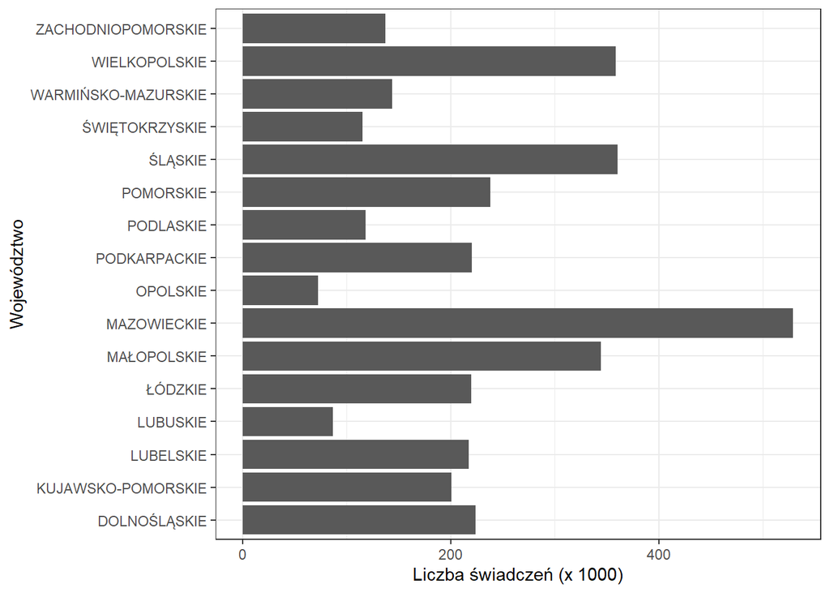

```r
d500plus_woj %>%
  group_by(woj_name) %>%
  summarise(suma=sum(val)/1000) %>%
  ggplot(aes(x=suma, y=woj_name)) +
  geom_col() +
  ylab("Województwo") +
  xlab("Liczba świadczeń (x 1000)") +
  theme_bw()
```

## Próba prosta

W pierwszej kolejności wylosowano dwie próby proste o liczebności 248 gmin (10% wszystkich gmin) i 496 gmin (20% wszystkich gmin). Udział liczebności gmin w próbie i populacji jest przedstawiony na poniższym wykresie.

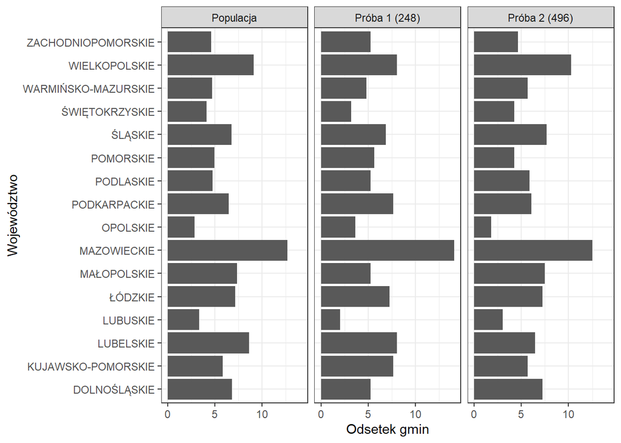

```r
set.seed(123)

proba_prosta1 <- d500plus_woj %>%
  sample_n(248) %>%
  mutate(prob=248/nrow(d500plus_woj),
         waga=1/prob)

proba_prosta2 <- d500plus_woj %>%
  sample_n(496) %>%
  mutate(prob=496/nrow(d500plus_woj),
         waga=1/prob)

woj_count1 <- proba_prosta1 %>%
  count(woj_name) %>%
  mutate(proc=n/248*100,
         d = "Próba 1 (248)")

woj_count2 <- proba_prosta2 %>%
  count(woj_name) %>%
  mutate(proc=n/496*100,
         d = "Próba 2 (496)")

woj_count_pop <- d500plus_woj %>%
  count(woj_name) %>%
  mutate(proc=n/2478*100,
         d = "Populacja")

woj_count_all <- union_all(woj_count_pop, union_all(woj_count1, woj_count2))

ggplot(woj_count_all, aes(x=proc, y=woj_name)) +
  geom_col() +
  facet_wrap(~ d) +
  xlab("Odsetek gmin") +
  ylab("Województwo") +
  theme_bw()
```

Można zauważyć, że w próbie nr 1 gminy w województwie Mazowieckim są nadreprezentowane, a w województwie lubuskim niedoreprezentowane. W próbie nr 2 niedoreprezentowane są gminy m.in. z województwa lubelskiego.

W wylosowanych próbach wagi sumują się do liczebności populacji.

Następnie oszacowano wartość globalną liczby dzieci otrzymujących świadczenie 500 plus.

```r
schemat1 <- svydesign(ids = ~1, weights = ~waga, data = proba_prosta1)

total_schemat1 <- svytotal(~val, schemat1)

cv_total_schemat1 <- round(as.numeric(cv(total_schemat1))*100,2)

ci_total_schemat1 <- confint(total_schemat1, level = 0.9)

schemat2 <- svydesign(ids = ~1, weights = ~waga, data = proba_prosta2)

total_schemat2 <- svytotal(~val, schemat2)

cv_total_schemat2 <- round(as.numeric(cv(total_schemat2))*100,2)

ci_total_schemat2 <- confint(total_schemat2, level = 0.9)
```

Na podstawie próby nr 1 uzyskano wynik 3867878 ze względnym błędem oszacowania równym 11,03%. 90% przedział ufności jest tworzony przez zakres wartości od 3166036 do 4569721. Z kolei w próbie drugiej oszacowanie wynosiło 3375336, a względny błąd 6,96%. W tym przypadku można stwierdzić, że wartość prawdziwa liczby dzieci otrzymujących 500 plus z 90% prawdopodobieństwm zawiera się w przedziale od 2988734 od 3761938.

Wyniki na poziomie województw przedstawione są na kolejnym wykresie z wykorzystaniem 90% przedziałów ufności. Z kolei czerwony punkt oznacza wartość w populacji.

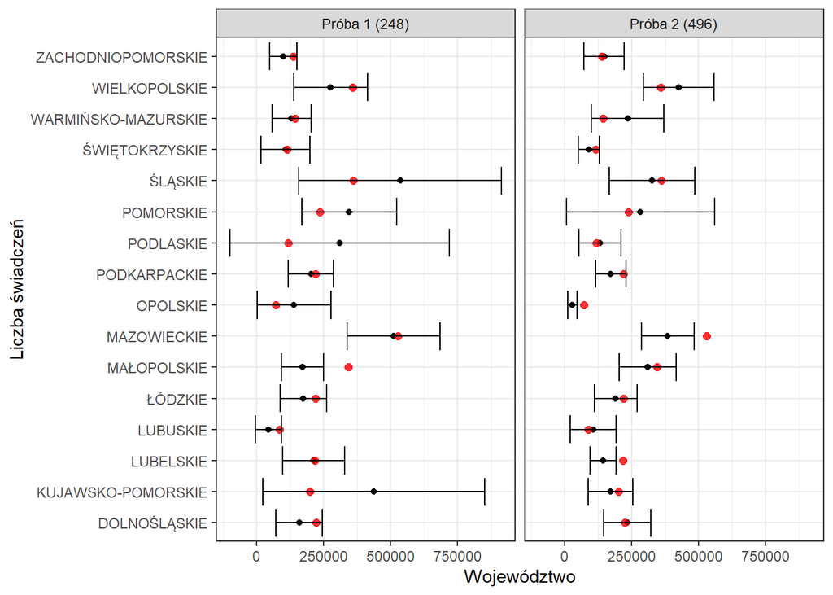

```r
pop_woj <- d500plus_woj %>%
  group_by(woj_name) %>%
  summarise(pop=sum(val))

total_schemat1_woj <- svyby(formula = ~val, by = ~woj_name, design = schemat1, FUN = svytotal)

total_schemat1_woj_ci <- as.data.frame(confint(total_schemat1_woj, level = 0.90))
names(total_schemat1_woj_ci) <- c("lower", "upper")

total_schemat1_woj_ci <- inner_join(cbind(total_schemat1_woj, total_schemat1_woj_ci),pop_woj) %>%
  mutate(d = "Próba 1 (248)")

total_schemat2_woj <- svyby(formula = ~val, by = ~woj_name, design = schemat2, FUN = svytotal)

total_schemat2_woj_ci <- as.data.frame(confint(total_schemat2_woj, level = 0.90))
names(total_schemat2_woj_ci) <- c("lower", "upper")

total_schemat2_woj_ci <- inner_join(cbind(total_schemat2_woj, total_schemat2_woj_ci),pop_woj) %>%
  mutate(d = "Próba 2 (496)")

total_woj <- union_all(total_schemat1_woj_ci, total_schemat2_woj_ci)

ggplot(total_woj, aes(y=woj_name, x=val)) +
  geom_point() +
  geom_point(aes(x=pop), color = "red", size = 2, alpha = 0.8) +
  geom_errorbar(aes(xmin = lower, xmax = upper)) +
  xlab("Województwo") +
  ylab("Liczba świadczeń") +
  facet_wrap(~ d) +
  theme_bw()
```

W próbie nr 1, tylko w przypadku województwa małopolskiego wartość prawdziwa znajduje się poza przedziałem ufności. Najszersze przedziały ufności występowały w województwach: śląskim, podlaskim oraz kujawsko-pomorskim. W 2 przypadkach wartości granic przedziałów ufności były mniejsze od 0. W drugiej próbie przedziały ufności są dużo węższe, ale aż w trzech przypadkach wartość z populacji się w nich nie znalazła - dla województw: opolskiego, mazowieckiego i lubelskiego.

## Próba warstwowa

W celu uzyskania bardziej adekwatnych oszacowań uwzględniających strukturę populacji przeprowadzono warstwowanie próby z wykorzystaniem województwa oraz 3 przedziałów przeciętnego wynagrodzenia.

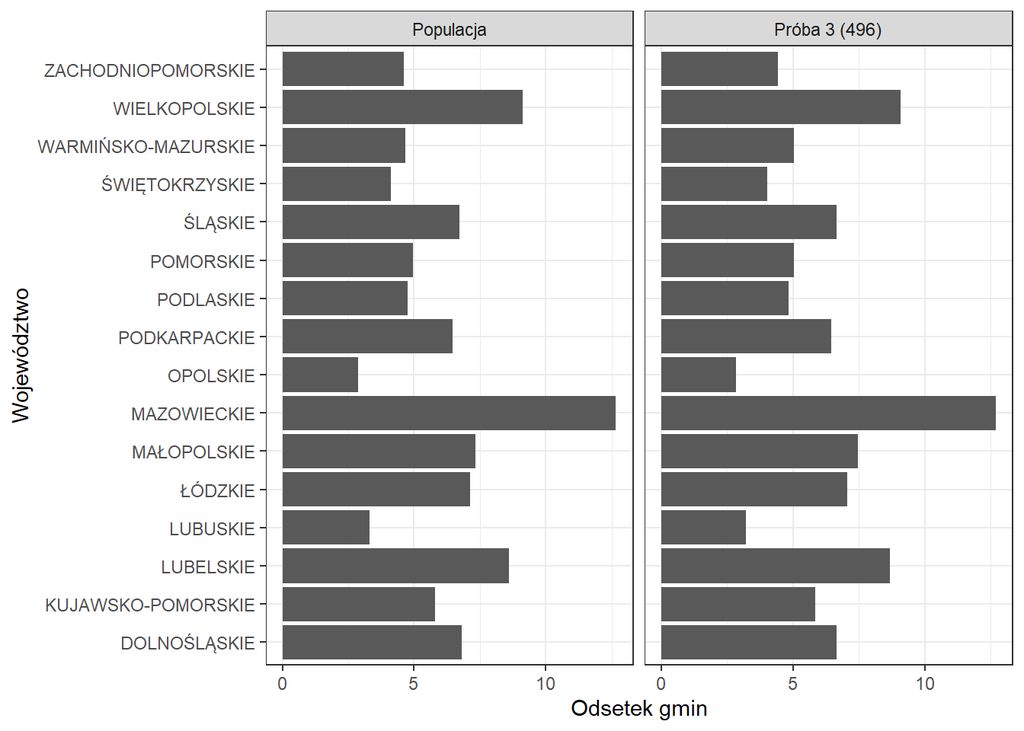

```r
wyn <- get_data_by_variable(varId = 64428, year = 2018, unitLevel = 5) %>%
  mutate(kod_pow=str_c(str_sub(id,3,4),str_sub(id,8,9)))

wyn_class <- classInt::classIntervals(var = wyn$val, n = 3, style = "quantile")

wyn$wyn_cat <- cut(wyn$val, breaks = wyn_class$brks, labels = c("1","2","3"), include.lowest = T)

d500plus_woj_wyn <- left_join(d500plus_woj, select(wyn, kod_pow, wyn_cat)) %>%
  mutate(warstwa=str_c(kod_woj,wyn_cat))

set.seed(123)

proba_warstwa_size <- d500plus_woj_wyn %>%
  count(warstwa) %>%
  mutate(n_proba=round(0.2*n),
         n_proba=ifelse(n_proba == 0, 2, n_proba))

d500plus_woj_wyn <- d500plus_woj_wyn %>%
  arrange(warstwa)

proba_warstwa <- strata(d500plus_woj_wyn, stratanames = "warstwa", size = proba_warstwa_size$n_proba)

proba_warstwa_d500 <- getdata(d500plus_woj_wyn, proba_warstwa) %>%
  mutate(waga=1/Prob)

woj_count3 <- proba_warstwa_d500 %>%
  count(woj_name) %>%
  mutate(proc=n/nrow(proba_warstwa_d500)*100,
         d = "Próba 3 (496)")

woj_count_all_3 <- union_all(woj_count_pop, woj_count3)

ggplot(woj_count_all_3, aes(x=proc, y=woj_name)) +
  geom_col() +
  facet_wrap(~ d) +
  xlab("Odsetek gmin") +
  ylab("Województwo") +
  theme_bw()
```

Dzięki zastosowaniu losowania warstwowego struktura w podziale na województwa jest zachowana.

```r
schemat3 <- svydesign(ids = ~1, weights = ~waga, strata = ~warstwa, data = proba_warstwa_d500)

total_schemat3 <- svytotal(~val, schemat3)

cv_total_schemat3 <- round(as.numeric(cv(total_schemat3))*100,2)

ci_total_schemat3 <- confint(total_schemat3, level = 0.9)
```

Oszacowanie liczby świadczeń na podstawie próby nr 3 wynosi 3785167 ze względnym błędem standardowym 11,14%. 90% przedział ufności pokrywa wartości od 3091644 do 4478691 dzieci.

Wyniki w podziale na województwa przedstawione są poniżej:

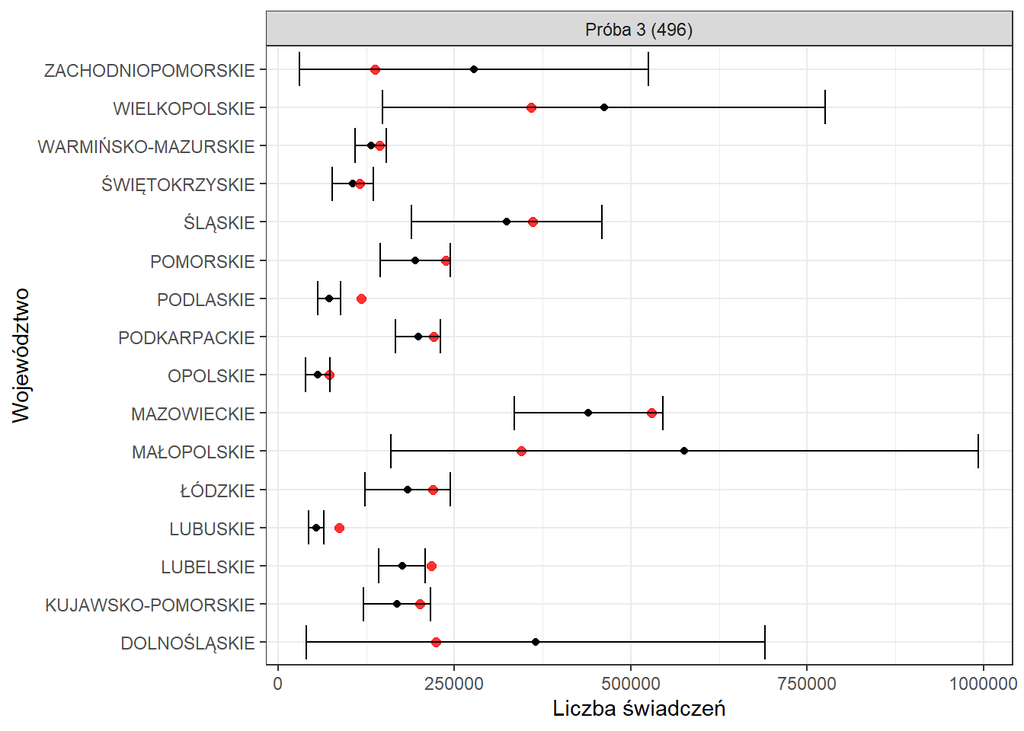

```r
total_schemat3_woj <- svyby(formula = ~val, by = ~woj_name, design = schemat3, FUN = svytotal)

total_schemat3_woj_ci <- as.data.frame(confint(total_schemat3_woj, level = 0.90))
names(total_schemat3_woj_ci) <- c("lower", "upper")

total_schemat3_woj_ci <- inner_join(cbind(total_schemat3_woj, total_schemat3_woj_ci),pop_woj) %>%
  mutate(d = "Próba 3 (496)")

ggplot(total_schemat3_woj_ci, aes(y=woj_name, x=val)) +
  geom_point() +
  geom_point(aes(x=pop), color = "red", size = 2, alpha = 0.8) +
  geom_errorbar(aes(xmin = lower, xmax = upper)) +
  ylab("Województwo") +
  xlab("Liczba świadczeń") +
  facet_wrap(~ d) +
  theme_bw()
```

W przypadku tej próby obserwuje się bardzo szerokie przedziały ufności dla 5 województw. W trzech przypadkach wartość prawdziwa znajdowała się poza stworzonymi przedziałami. Co istotne, w żadnym przypadku dolne granice przedziałów ufności nie były mniejsze od zera.

## Podsumowanie

Projekt przedstawia 3 podejścia do losowania próby w celu oszacowania liczby dzieci, na które rodziny otrzymują świadczenie 500 plus. W przypadku zastosowania próby prostej nie zachowana została struktura liczebności gmin wg województw. Jako alternatywę użyto losowania warstwowego uwzględniając województwo oraz wynagrodzenie. Pomimo tej operacji i wylosowania aż 20% gmin, otrzymane wyniki nie cechują się adekwatną precyzją dla wszystkich jednostek terytorialnych. Należy rozważyć inne sposoby warstwowania uwzględniające specyfikę poszczególnych województw.